# Predicting Fat Content of Canadian Cheese

**`by Nyanda Redwood`**

# Introduction

## Objective

The objective first entails doing an exploratory analysis and then predicting the level of fat in our target column, **`FatLevel`**, of each example.

Since the level of fat can either be "lower fat" or "higher fat" this question is a classification question. The positive label for this data is **`FatLevel`**.

## Rationale

For cheese lovers who are also health conscious, knowing the level of fat in a type of cheese may assist in selection choices. This is especially the case in today's world of health-conscious eaters.

## Description of the Dataset

The dataset deals with varous types of Canadian cheese. It was obtained from Kaggle and can be found [here](https://open.canada.ca/data/en/dataset/3c16cd48-3ac3-453f-8260-6f745181c83b). It adheres to [Open Government Licence (Canada)](https://open.canada.ca/en/open-government-licence-canada).

## Methods and Results

To begin let's import the possible libraries needed for our analysis.

```python
# Import libraries needed for this analysis.
import altair as alt
import numpy as np
import pandas as pd
import string
from sklearn import tree
from sklearn.dummy import DummyClassifier
from sklearn.tree import DecisionTreeClassifier
from sklearn.model_selection import train_test_split, cross_validate
from sklearn.neighbors import KNeighborsClassifier
from sklearn.impute import KNNImputer
from sklearn.impute import SimpleImputer
from sklearn.pipeline import Pipeline, make_pipeline
from sklearn.compose import make_column_transformer
from sklearn.model_selection import GridSearchCV, RandomizedSearchCV
from sklearn.feature_extraction.text import CountVectorizer
from sklearn.linear_model import LogisticRegression
from sklearn.ensemble import RandomForestClassifier, RandomForestRegressor
from sklearn.preprocessing import (
    FunctionTransformer,
    Normalizer,
    OneHotEncoder,
    OrdinalEncoder,
    StandardScaler,
    normalize,
    scale,
    )
from sklearn.metrics import plot_confusion_matrix, classification_report
from sklearn.svm import SVC, SVR
```

Let's import the tables and split it into training and test sets.

```python
# Read in our table cheese_data.csv.
cheese_df = pd.read_csv("cheese_data.csv")

# Convert our table to a dataframe.
cheese_df = pd.DataFrame(cheese_df)
cheese_df

# Remove NaN values in our target feature, FatLevel.
cheese_df = cheese_df.dropna(subset=["FatLevel"])
cheese_df.head()

# Let's drop the columns suggested to drop in the instructions. This is after trying multiple times to transform them.
cheese_df = cheese_df.drop(columns=["CheeseId", "FlavourEn", "CharacteristicsEn", "RindTypeEn", "CheeseName"])
cheese_df
```

|  | ManufacturerProvCode | ManufacturingTypeEn | MoisturePercent | Organic | CategoryTypeEn | MilkTypeEn | MilkTreatmentTypeEn | FatLevel |
| --- | --- | --- | --- | --- | --- | --- | --- | --- |
| 0 | NB | Farmstead | 47.0 | 0 | Firm Cheese | Ewe | Raw Milk | lower fat |
| 1 | NB | Farmstead | 47.9 | 0 | Semi-soft Cheese | Cow | Raw Milk | lower fat |
| 2 | ON | Industrial | 54.0 | 0 | Firm Cheese | Cow | Pasteurized | lower fat |
| 3 | NB | Farmstead | 47.0 | 0 | Veined Cheeses | Cow | Raw Milk | lower fat |
| 4 | NB | Farmstead | 49.4 | 1 | Semi-soft Cheese | Cow | Raw Milk | lower fat |
| ... | ... | ... | ... | ... | ... | ... | ... | ... |
| 1037 | NS | Farmstead | 37.0 | 1 | Hard Cheese | Cow | Pasteurized | higher fat |
| 1038 | AB | Industrial | 46.0 | 0 | Fresh Cheese | Cow | Pasteurized | lower fat |
| 1039 | NS | Artisan | 40.0 | 0 | Veined Cheeses | Ewe | Thermised | higher fat |
| 1040 | NS | Artisan | 34.0 | 0 | Semi-soft Cheese | Ewe | Thermised | higher fat |
| 1041 | AB | Artisan | 31.5 | 0 | Fresh Cheese | Cow | Pasteurized | higher fat |

1042 rows × 8 columns

To adhere to the Golden Rule, let's now split our dataset before anything else.

```python
# Split cheese_df in to training and test sets.
train_df, test_df = train_test_split(cheese_df, test_size=0.2, random_state=77)
train_df.head()
```

|  | ManufacturerProvCode | ManufacturingTypeEn | MoisturePercent | Organic | CategoryTypeEn | MilkTypeEn | MilkTreatmentTypeEn | FatLevel |
| --- | --- | --- | --- | --- | --- | --- | --- | --- |
| 110 | ON | Industrial | 52.0 | 0 | Semi-soft Cheese | Cow | Pasteurized | lower fat |
| 762 | ON | Industrial | 40.0 | 0 | Firm Cheese | Cow | Pasteurized | higher fat |
| 898 | QC | Artisan | 48.0 | 0 | Semi-soft Cheese | Cow | Pasteurized | lower fat |
| 260 | QC | Industrial | 55.0 | 0 | Soft Cheese | Cow | Raw Milk | lower fat |
| 223 | QC | Artisan | 60.0 | 0 | Fresh Cheese | Goat | Pasteurized | lower fat |

From the above, we note that the values in the **`MoisturePercent`** column will result in an unbalanced dataset given the other numeric values in **`Organic`** column. Later, we will use StandardScaler() to balance our dataset. At present, let's find out some more about the training set.

```python
# Use .describe() and .info() to find out more info.
train_df.info()
train_df.describe()
```

```
<class 'pandas.core.frame.DataFrame'>
Int64Index: 833 entries, 110 to 727
Data columns (total 8 columns):
 #   Column                Non-Null Count  Dtype
---  ------                --------------  -----
 0   ManufacturerProvCode  833 non-null    object
 1   ManufacturingTypeEn   833 non-null    object
 2   MoisturePercent       823 non-null    float64
 3   Organic               833 non-null    int64
 4   CategoryTypeEn        814 non-null    object
 5   MilkTypeEn            832 non-null    object
 6   MilkTreatmentTypeEn   779 non-null    object
 7   FatLevel              833 non-null    object
dtypes: float64(1), int64(1), object(6)
memory usage: 58.6+ KB
```

|  | MoisturePercent | Organic |
| --- | --- | --- |
| count | 823.000000 | 833.000000 |
| mean | 46.955043 | 0.094838 |
| std | 9.557279 | 0.293167 |
| min | 12.000000 | 0.000000 |
| 25% | 40.000000 | 0.000000 |
| 50% | 46.000000 | 0.000000 |
| 75% | 52.000000 | 0.000000 |
| max | 88.000000 | 1.000000 |

There are 833 examples in the train_df. Four features in the training set have null values. Let's drop the **`MilkTreatmentTypeEn`** column, and try to impute the missing values in the other columns later since those columns have under 20 missing values each. This is given that dropping columns are not ideal and leads to skewed datasets.

```python
train_df = train_df.drop(columns=["MilkTreatmentTypeEn"])
train_df
```

|  | ManufacturerProvCode | ManufacturingTypeEn | MoisturePercent | Organic | CategoryTypeEn | MilkTypeEn | FatLevel |
| --- | --- | --- | --- | --- | --- | --- | --- |
| 110 | ON | Industrial | 52.0 | 0 | Semi-soft Cheese | Cow | lower fat |
| 762 | ON | Industrial | 40.0 | 0 | Firm Cheese | Cow | higher fat |
| 898 | QC | Artisan | 48.0 | 0 | Semi-soft Cheese | Cow | lower fat |
| 260 | QC | Industrial | 55.0 | 0 | Soft Cheese | Cow | lower fat |
| 223 | QC | Artisan | 60.0 | 0 | Fresh Cheese | Goat | lower fat |
| ... | ... | ... | ... | ... | ... | ... | ... |
| 736 | QC | Artisan | 55.0 | 1 | Firm Cheese | Cow | lower fat |
| 927 | NS | Industrial | 40.0 | 0 | NaN | Cow | lower fat |
| 235 | QC | Artisan | 50.0 | 0 | Soft Cheese | Cow | higher fat |
| 607 | QC | Industrial | 41.0 | 0 | Firm Cheese | Cow | higher fat |
| 727 | QC | Farmstead | 39.0 | 1 | Firm Cheese | Cow | higher fat |

833 rows × 7 columns

Find the distribution of our target values in **`FatLevel`**.

```python
class_dist = train_df.value_counts('FatLevel')
class_dist
```

```
FatLevel
lower fat     546
higher fat    287
dtype: int64
```

Here we see that lower fat levels have a higher distribution spread than higher fat levels. This ties into the rationale of cheese eaters wanting cheese but not with too much fat. It also shows that the classes are not balanced.

Before preprocessing let's separate the feature vectors from the target feature, **`FatLevel`**.

```python
# Separate feature vectors from the target, CategoryTypeEn.
X_train = train_df.drop(columns=["FatLevel"])
y_train= train_df["FatLevel"]

X_test = test_df.drop(columns=["FatLevel"])
y_test = test_df["FatLevel"]
X_train.head()
```

|  | ManufacturerProvCode | ManufacturingTypeEn | MoisturePercent | Organic | CategoryTypeEn | MilkTypeEn |
| --- | --- | --- | --- | --- | --- | --- |
| 110 | ON | Industrial | 52.0 | 0 | Semi-soft Cheese | Cow |
| 762 | ON | Industrial | 40.0 | 0 | Firm Cheese | Cow |
| 898 | QC | Artisan | 48.0 | 0 | Semi-soft Cheese | Cow |
| 260 | QC | Industrial | 55.0 | 0 | Soft Cheese | Cow |
| 223 | QC | Artisan | 60.0 | 0 | Fresh Cheese | Goat |

To further understand our training data set, let's take a look at how some of the features interact with the target.

```python
#Visualize the relationship between Moisture Percent & Type of Cheese.
#Let's focus on the columns we want to plot
columns_to_plot = train_df[["MoisturePercent", "CategoryTypeEn"]]
columns_to_plot

# Using groubby, mean, and resetindex(), plot columns "MositurePercent" and "CategoryTypeEn".
moist_type = columns_to_plot.groupby(by="CategoryTypeEn").mean()
moist_type = columns_to_plot.reset_index()
moist_type

# Use moist_type to plot.
plot1 = alt.Chart(moist_type, width = 300, height=500).mark_bar().encode(
alt.X('CategoryTypeEn'),
alt.Y('MoisturePercent')).properties(title= "Type of Cheese Based on Moisture Content")

plot1
```

[interactive chart not shown]

In the above diagram, plot1, the cheese with the three highest moisture content, from highest to lowest, are: Soft cheese, Fresh cheese, and Semi-soft cheese. Firm and Hard cheese contain equal amounts of moisture, and both contain more than Veined cheese, which contains the least amount of moisture.

```python
#Visualize the relationship between Moisture Percent & Type of Milk.
#Let's focus on the columns we want to plot
cols_to_plot = train_df[["MoisturePercent", "MilkTypeEn"]]
cols_to_plot

# Using groubby, mean, and resetindex(), plot columns "MositurePercent" and "CategoryTypeEn".
milk_type = cols_to_plot.groupby(by="MilkTypeEn").mean()
milk_type = cols_to_plot.reset_index()
milk_type

# Use moist_type to plot.
plot2 = alt.Chart(milk_type, width = 300, height=500).mark_bar().encode(
alt.X('MilkTypeEn'),
alt.Y('MoisturePercent')).properties(title= "Type of Milk vs. Cheese Moisture Content")

plot2
```

[interactive chart not shown]

There are 8 different types of milk that are used in the production of the cheese in our dataset. In the above diagram, plot2, the types of milk that corresponds with the three highest cheese moisture content, from highest to lowest, are: **Cow**, **Buffalo Cow**, and **Ewe**. Mixed milks from **Cow & Goat** and **Ewe and Goat** corresponds with cheese that contain equal amounts of moisture, and this moisture content ranks the fith highest. It's notable that both these mixed types have Goat's milk as a component. The mixed milk from **Ewe and Cow** corresponds with cheese that contain the least amount of moisture.

## Build Base Model with which to Compare Models

```python
# Save our base model as dummy.
dummy = DummyClassifier(strategy='most_frequent')

# Use dummy to fit on the training set.
dummy.fit(X_train, y_train)

# Cross validate and save the results as a dataframe in the object dummy_scores. Be sure to return the train score.
dummy_scores = pd.DataFrame(cross_validate(dummy, X_train, y_train, cv=5, return_train_score=True))
dummy_scores
```

|  | fit_time | score_time | test_score | train_score |
| --- | --- | --- | --- | --- |
| 0 | 0.002138 | 0.000950 | 0.658683 | 0.654655 |
| 1 | 0.001704 | 0.000832 | 0.652695 | 0.656156 |
| 2 | 0.001683 | 0.000829 | 0.652695 | 0.656156 |
| 3 | 0.001673 | 0.000833 | 0.656627 | 0.655172 |
| 4 | 0.001823 | 0.000910 | 0.656627 | 0.655172 |

Find the mean of the results in dummy_scores.

```python
# Find the mean of each column in dummy_scores, and save object as dummy_mean.
dummy_mean = dummy_scores.mean()
dummy_mean
```

```
fit_time       0.001804
score_time     0.000871
test_score     0.655465
train_score    0.655462
dtype: float64
```

## Preprocessing the Data and Pipeline Building

In order to preprocess, first separate the features into their types (binary, ordinal etc.).

```python
X_train.dtypes
```

```
ManufacturerProvCode     object
ManufacturingTypeEn      object
MoisturePercent         float64
Organic                   int64
CategoryTypeEn           object
MilkTypeEn               object
dtype: object
```

```python
# Separate columns into feature types.
numeric_features = ["MoisturePercent"]
categorical_features = ["ManufacturerProvCode", "ManufacturingTypeEn", "CategoryTypeEn", "MilkTypeEn"]
binary_features = ["Organic"]
target = ["FatLevel"]
```

```python
# Make a pipeline for each of the four feature types.
numeric_transformer = make_pipeline(
    SimpleImputer(strategy='median'),
    StandardScaler()
)
#catergorical_transformer = make_pipeline(
#    KNNImputer(n_neighbors=2)
#)

# Make a preprocessor with these piplines.
preprocessor = make_column_transformer(
                                      (numeric_transformer, numeric_features)
                                      #(catergorical_transformer, categorical_features)
                                      )
```

Noted Issues: KNNImputer seems the most logical to replace the missing values in these categorical features. Hence, I attempted using it. However, attempting to transform these missing categorical features result in an error with which I am unfamiliar.

## Build Models with which to Compare Base Model

```python
# Use RandomForestClassifier to build a pipe, rfc_pipe.
rfc_pipe = make_pipeline(preprocessor, RandomForestClassifier(class_weight ="balanced", random_state=77, n_estimators=10))
#rfc_pipe
```

```python
# Fit rfc_pipe on the training set.
rfc_pipe.fit(X_train, y_train)

# Cross validate on the training using rfc_pipe. Save the results in a DataFrame.
rfc_scores =pd.DataFrame(cross_validate(rfc_pipe, X_train, y_train, cv=5, return_train_score=True))
rfc_scores
```

|  | fit_time | score_time | test_score | train_score |
| --- | --- | --- | --- | --- |
| 0 | 0.051287 | 0.005451 | 0.802395 | 0.809309 |
| 1 | 0.026019 | 0.005508 | 0.796407 | 0.822823 |
| 2 | 0.026973 | 0.005722 | 0.784431 | 0.827327 |
| 3 | 0.026628 | 0.005763 | 0.813253 | 0.833583 |
| 4 | 0.026190 | 0.005422 | 0.777108 | 0.827586 |

Find the mean of rfc_scores.

```python
rfc_mean_scores = rfc_scores.mean()
rfc_mean_scores
```

```
fit_time       0.031419
score_time     0.005573
test_score     0.794719
train_score    0.824126
dtype: float64
```

In comparisson to the DummyClassifier, the scores from RandomClassifier are noticeably higher.

Let's tune the hyperparameters n_estimators and max_depth. For speed, **RandomizedSearchCV** is used below and not **GridSearchCV**.

```python
import scipy
from scipy.stats import randint

rf_pipeline = make_pipeline(
    preprocessor, RandomForestClassifier(random_state=123)
)

param_dist = {
    "randomforestclassifier__n_estimators": scipy.stats.randint(low=10, high=300),
    "randomforestclassifier__max_depth": scipy.stats.randint(low=2, high=20),
}

random_search = RandomizedSearchCV(
    rf_pipeline,
    param_dist,
    n_iter=50,
    cv=3,
    verbose=1,
    n_jobs=-1,
    scoring="accuracy",
    random_state=123,
)
random_search.fit(X_train, y_train)
```

```
Fitting 3 folds for each of 50 candidates, totalling 150 fits
```

```
[Parallel(n_jobs=-1)]: Using backend SequentialBackend with 1 concurrent workers.
[Parallel(n_jobs=-1)]: Done 150 out of 150 | elapsed:   54.6s finished
```

```
RandomizedSearchCV(cv=3,
                   estimator=Pipeline(steps=[('columntransformer',
                                              ColumnTransformer(transformers=[('pipeline',
                                                                               Pipeline(steps=[('simpleimputer',
                                                                                                SimpleImputer(strategy='median')),
                                                                                               ('standardscaler',
                                                                                                StandardScaler())]),
                                                                               ['MoisturePercent'])])),
                                             ('randomforestclassifier',
                                              RandomForestClassifier(random_state=123))]),
                   n_iter=50, n_jobs=-1,
                   param_distributions={'randomforestclassifier__max_depth': <scipy.stats._distn_infrastructure.rv_frozen object at 0x7fafaba541f0>,
                                        'randomforestclassifier__n_estimators': <scipy.stats._distn_infrastructure.rv_frozen object at 0x7fb008063430>},
                   random_state=123, scoring='accuracy', verbose=1)
```

```python
# Calculate the best hyperparameter value for n_estimator and max_depth, and save as optimal_parameters.
optimal_parameters = random_search.best_params_

# Calculate the corresponding validation score, and save as optimal_score.
optimal_score = random_search.best_score_

optimal_parameters, optimal_score
```

```
({'randomforestclassifier__max_depth': 4,
  'randomforestclassifier__n_estimators': 86},
 0.8391207611528108)
```

```python
pd.DataFrame(random_search.cv_results_)
```

|  | mean_fit_time | std_fit_time | mean_score_time | std_score_time | param_randomforestclassifier__max_depth | param_randomforestclassifier__n_estimators | params | split0_test_score | split1_test_score | split2_test_score | mean_test_score | std_test_score | rank_test_score |
| --- | --- | --- | --- | --- | --- | --- | --- | --- | --- | --- | --- | --- | --- |
| 0 | 0.331725 | 0.077539 | 0.032528 | 0.019124 | 15 | 108 | {'randomforestclassifier__max_depth': 15, 'ran... | 0.812950 | 0.830935 | 0.823105 | 0.822330 | 0.007363 | 30 |
| 1 | 0.102523 | 0.000857 | 0.025895 | 0.025093 | 8 | 27 | {'randomforestclassifier__max_depth': 8, 'rand... | 0.848921 | 0.830935 | 0.823105 | 0.834320 | 0.010808 | 11 |
| 2 | 0.303260 | 0.087150 | 0.021839 | 0.000461 | 12 | 133 | {'randomforestclassifier__max_depth': 12, 'ran... | 0.812950 | 0.830935 | 0.823105 | 0.822330 | 0.007363 | 30 |
| 3 | 0.191019 | 0.014026 | 0.017223 | 0.000106 | 3 | 106 | {'randomforestclassifier__max_depth': 3, 'rand... | 0.823741 | 0.830935 | 0.794224 | 0.816300 | 0.015884 | 50 |
| 4 | 0.231748 | 0.000398 | 0.022035 | 0.000101 | 19 | 136 | {'randomforestclassifier__max_depth': 19, 'ran... | 0.812950 | 0.830935 | 0.823105 | 0.822330 | 0.007363 | 30 |
| 5 | 0.144045 | 0.000617 | 0.015136 | 0.000038 | 17 | 83 | {'randomforestclassifier__max_depth': 17, 'ran... | 0.812950 | 0.830935 | 0.823105 | 0.822330 | 0.007363 | 30 |
| 6 | 0.516825 | 0.196975 | 0.056090 | 0.020712 | 2 | 234 | {'randomforestclassifier__max_depth': 2, 'rand... | 0.823741 | 0.834532 | 0.794224 | 0.817499 | 0.017038 | 48 |
| 7 | 0.543147 | 0.144627 | 0.038659 | 0.000286 | 17 | 263 | {'randomforestclassifier__max_depth': 17, 'ran... | 0.859712 | 0.830935 | 0.823105 | 0.837917 | 0.015739 | 2 |
| 8 | 0.183514 | 0.004120 | 0.017750 | 0.000148 | 6 | 106 | {'randomforestclassifier__max_depth': 6, 'rand... | 0.848921 | 0.830935 | 0.819495 | 0.833117 | 0.012112 | 21 |
| 9 | 0.133319 | 0.000534 | 0.014739 | 0.000473 | 18 | 78 | {'randomforestclassifier__max_depth': 18, 'ran... | 0.812950 | 0.830935 | 0.823105 | 0.822330 | 0.007363 | 30 |
| 10 | 0.028422 | 0.000205 | 0.005883 | 0.000037 | 19 | 12 | {'randomforestclassifier__max_depth': 19, 'ran... | 0.802158 | 0.830935 | 0.815884 | 0.816326 | 0.011752 | 49 |
| 11 | 0.159848 | 0.001479 | 0.016423 | 0.000212 | 9 | 94 | {'randomforestclassifier__max_depth': 9, 'rand... | 0.812950 | 0.830935 | 0.823105 | 0.822330 | 0.007363 | 30 |
| 12 | 0.576944 | 0.202765 | 0.048440 | 0.028127 | 17 | 186 | {'randomforestclassifier__max_depth': 17, 'ran... | 0.859712 | 0.830935 | 0.823105 | 0.837917 | 0.015739 | 2 |
| 13 | 0.209562 | 0.034557 | 0.018636 | 0.000145 | 9 | 109 | {'randomforestclassifier__max_depth': 9, 'rand... | 0.812950 | 0.830935 | 0.823105 | 0.822330 | 0.007363 | 30 |
| 14 | 0.366484 | 0.001565 | 0.032819 | 0.000174 | 8 | 223 | {'randomforestclassifier__max_depth': 8, 'rand... | 0.823741 | 0.830935 | 0.823105 | 0.825927 | 0.003551 | 24 |
| 15 | 0.147373 | 0.002531 | 0.014893 | 0.000209 | 4 | 86 | {'randomforestclassifier__max_depth': 4, 'rand... | 0.859712 | 0.830935 | 0.826715 | 0.839121 | 0.014662 | 1 |
| 16 | 0.197735 | 0.000750 | 0.019832 | 0.000382 | 10 | 116 | {'randomforestclassifier__max_depth': 10, 'ran... | 0.823741 | 0.830935 | 0.823105 | 0.825927 | 0.003551 | 24 |
| 17 | 0.131778 | 0.000986 | 0.014174 | 0.000247 | 7 | 74 | {'randomforestclassifier__max_depth': 7, 'rand... | 0.812950 | 0.830935 | 0.823105 | 0.822330 | 0.007363 | 30 |
| 18 | 0.896075 | 0.331163 | 0.061007 | 0.027608 | 13 | 288 | {'randomforestclassifier__max_depth': 13, 'ran... | 0.848921 | 0.830935 | 0.823105 | 0.834320 | 0.010808 | 11 |
| 19 | 0.265572 | 0.002656 | 0.025145 | 0.000460 | 15 | 156 | {'randomforestclassifier__max_depth': 15, 'ran... | 0.812950 | 0.830935 | 0.823105 | 0.822330 | 0.007363 | 30 |
| 20 | 0.481138 | 0.006048 | 0.056947 | 0.023123 | 6 | 281 | {'randomforestclassifier__max_depth': 6, 'rand... | 0.848921 | 0.830935 | 0.819495 | 0.833117 | 0.012112 | 21 |
| 21 | 0.675402 | 0.187252 | 0.038776 | 0.000480 | 13 | 263 | {'randomforestclassifier__max_depth': 13, 'ran... | 0.859712 | 0.830935 | 0.823105 | 0.837917 | 0.015739 | 2 |
| 22 | 0.285276 | 0.002086 | 0.026217 | 0.000139 | 14 | 168 | {'randomforestclassifier__max_depth': 14, 'ran... | 0.812950 | 0.830935 | 0.823105 | 0.822330 | 0.007363 | 30 |
| 23 | 0.297425 | 0.018099 | 0.028480 | 0.004288 | 8 | 164 | {'randomforestclassifier__max_depth': 8, 'rand... | 0.812950 | 0.830935 | 0.823105 | 0.822330 | 0.007363 | 30 |
| 24 | 0.704423 | 0.189644 | 0.057601 | 0.023561 | 18 | 280 | {'randomforestclassifier__max_depth': 18, 'ran... | 0.848921 | 0.830935 | 0.823105 | 0.834320 | 0.010808 | 11 |
| 25 | 0.276585 | 0.047089 | 0.024542 | 0.002814 | 9 | 139 | {'randomforestclassifier__max_depth': 9, 'rand... | 0.812950 | 0.830935 | 0.823105 | 0.822330 | 0.007363 | 30 |
| 26 | 0.355404 | 0.029212 | 0.029996 | 0.000536 | 13 | 196 | {'randomforestclassifier__max_depth': 13, 'ran... | 0.823741 | 0.830935 | 0.823105 | 0.825927 | 0.003551 | 24 |
| 27 | 0.319029 | 0.001217 | 0.029257 | 0.000166 | 7 | 193 | {'randomforestclassifier__max_depth': 7, 'rand... | 0.859712 | 0.830935 | 0.819495 | 0.836714 | 0.016920 | 7 |
| 28 | 0.834414 | 0.258244 | 0.042015 | 0.001910 | 19 | 278 | {'randomforestclassifier__max_depth': 19, 'ran... | 0.848921 | 0.830935 | 0.823105 | 0.834320 | 0.010808 | 11 |
| 29 | 0.031116 | 0.004062 | 0.006586 | 0.001098 | 19 | 11 | {'randomforestclassifier__max_depth': 19, 'ran... | 0.802158 | 0.830935 | 0.823105 | 0.818733 | 0.012148 | 47 |
| 30 | 0.506571 | 0.085655 | 0.042514 | 0.008361 | 14 | 243 | {'randomforestclassifier__max_depth': 14, 'ran... | 0.859712 | 0.830935 | 0.823105 | 0.837917 | 0.015739 | 2 |
| 31 | 0.115208 | 0.000566 | 0.013022 | 0.000245 | 18 | 66 | {'randomforestclassifier__max_depth': 18, 'ran... | 0.812950 | 0.830935 | 0.823105 | 0.822330 | 0.007363 | 30 |
| 32 | 0.031383 | 0.000472 | 0.005923 | 0.000074 | 19 | 13 | {'randomforestclassifier__max_depth': 19, 'ran... | 0.816547 | 0.830935 | 0.815884 | 0.821122 | 0.006944 | 45 |
| 33 | 0.254535 | 0.009813 | 0.031444 | 0.011920 | 5 | 149 | {'randomforestclassifier__max_depth': 5, 'rand... | 0.859712 | 0.830935 | 0.819495 | 0.836714 | 0.016920 | 7 |
| 34 | 0.091374 | 0.003542 | 0.008395 | 0.000060 | 9 | 13 | {'randomforestclassifier__max_depth': 9, 'rand... | 0.816547 | 0.830935 | 0.815884 | 0.821122 | 0.006944 | 45 |
| 35 | 0.799609 | 0.349644 | 0.063763 | 0.034132 | 13 | 269 | {'randomforestclassifier__max_depth': 13, 'ran... | 0.848921 | 0.830935 | 0.823105 | 0.834320 | 0.010808 | 11 |
| 36 | 0.463839 | 0.009719 | 0.040188 | 0.000284 | 8 | 275 | {'randomforestclassifier__max_depth': 8, 'rand... | 0.848921 | 0.830935 | 0.823105 | 0.834320 | 0.010808 | 11 |
| 37 | 0.480364 | 0.117370 | 0.072219 | 0.029799 | 16 | 208 | {'randomforestclassifier__max_depth': 16, 'ran... | 0.823741 | 0.830935 | 0.823105 | 0.825927 | 0.003551 | 24 |
| 38 | 0.155812 | 0.025367 | 0.009501 | 0.000308 | 14 | 37 | {'randomforestclassifier__max_depth': 14, 'ran... | 0.812950 | 0.830935 | 0.823105 | 0.822330 | 0.007363 | 30 |
| 39 | 0.288923 | 0.091333 | 0.020581 | 0.000161 | 8 | 126 | {'randomforestclassifier__max_depth': 8, 'rand... | 0.823741 | 0.830935 | 0.823105 | 0.825927 | 0.003551 | 24 |
| 40 | 0.364836 | 0.016724 | 0.034088 | 0.005467 | 5 | 203 | {'randomforestclassifier__max_depth': 5, 'rand... | 0.859712 | 0.830935 | 0.819495 | 0.836714 | 0.016920 | 7 |
| 41 | 0.052462 | 0.001492 | 0.007762 | 0.000166 | 17 | 26 | {'randomforestclassifier__max_depth': 17, 'ran... | 0.848921 | 0.830935 | 0.823105 | 0.834320 | 0.010808 | 11 |
| 42 | 0.202836 | 0.002016 | 0.019883 | 0.000493 | 7 | 119 | {'randomforestclassifier__max_depth': 7, 'rand... | 0.823741 | 0.830935 | 0.823105 | 0.825927 | 0.003551 | 24 |
| 43 | 0.721834 | 0.211548 | 0.080645 | 0.027278 | 16 | 281 | {'randomforestclassifier__max_depth': 16, 'ran... | 0.848921 | 0.830935 | 0.823105 | 0.834320 | 0.010808 | 11 |
| 44 | 0.527647 | 0.116083 | 0.038606 | 0.000264 | 10 | 266 | {'randomforestclassifier__max_depth': 10, 'ran... | 0.859712 | 0.830935 | 0.823105 | 0.837917 | 0.015739 | 2 |
| 45 | 0.122696 | 0.000360 | 0.013350 | 0.000155 | 5 | 70 | {'randomforestclassifier__max_depth': 5, 'rand... | 0.859712 | 0.830935 | 0.819495 | 0.836714 | 0.016920 | 7 |
| 46 | 0.602311 | 0.244097 | 0.054626 | 0.023302 | 3 | 264 | {'randomforestclassifier__max_depth': 3, 'rand... | 0.823741 | 0.830935 | 0.826715 | 0.827130 | 0.002952 | 23 |
| 47 | 0.470711 | 0.162008 | 0.027662 | 0.003776 | 14 | 145 | {'randomforestclassifier__max_depth': 14, 'ran... | 0.848921 | 0.830935 | 0.823105 | 0.834320 | 0.010808 | 11 |
| 48 | 0.166241 | 0.000129 | 0.016933 | 0.000168 | 8 | 98 | {'randomforestclassifier__max_depth': 8, 'rand... | 0.812950 | 0.830935 | 0.823105 | 0.822330 | 0.007363 | 30 |
| 49 | 0.257566 | 0.001570 | 0.024359 | 0.000125 | 8 | 151 | {'randomforestclassifier__max_depth': 8, 'rand... | 0.848921 | 0.830935 | 0.823105 | 0.834320 | 0.010808 | 11 |

Score the model on the test set.

```python
# Evaluate the best model from random_seach on the full training set.
training_score = random_search.score(X_train, y_train)
training_score
```

```
0.8379351740696278
```

```python
# Evaluate the best model from random_seach on the full test set.
test_score = random_search.score(X_test, y_test)
test_score
```

```
0.8325358851674641
```

- Significance of Error: the calculated scores could be slightly or extremely skewed.

```
<sklearn.metrics._plot.confusion_matrix.ConfusionMatrixDisplay at 0x7fafaa1f1100>
```

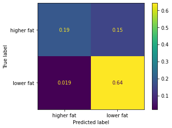

```python
# Plot a confusion matrix on the test set using random_search
cm_plot = plot_confusion_matrix(random_search, X_test, y_test, normalize="all")
cm_plot
```

```python
# Print a classification report on X_test of random_search's best model.
print(classification_report(y_test, random_search.predict(X_test)))
```

```
              precision    recall  f1-score   support

  higher fat       0.91      0.56      0.70        71
   lower fat       0.81      0.97      0.88       138

    accuracy                           0.83       209
   macro avg       0.86      0.77      0.79       209
weighted avg       0.85      0.83      0.82       209
```

[output not shown]

# Discussion

In order to carry out the analysis, it was necessary to wrangle features within the cheese dataset to compile relevant data in a form that readily and clearly facilitated the analysis, especially via vizualization.

Unexpectedly, there were errors in the wrangling of the dataset that led to column dropping. However, strong efforts were made to drop the least amount of columns. Still, of the remaining columns, missing categorical features were unsuccessfully imputed. This resulted in warnings of mismatched features, which could be of slight to severe consequences in our metric scores.

I, unsuccessfully, tried a lot of different ideas as Veined cheese piqued my curiosity, see below. However,I think for the unsuccessfull categorical transformations I could have tried a different method such as finding the value "ON" that seemed to have been the issue and drop it from these features. It possibly could have been found by using`.unique()`.

Another question that could be explored is: "what features predict the production Veined cheese?" It seems that outside the world of cheese connoisseurs Veined cheese is rarely known. Thus, knowing about features that lead to the production of it could provide insight on this type of cheese.

# Reference

This analysis relies heavily on external resources, from data to coding. Credits are shared among all particiapting resources including the notebook's author.

- Data Source: The cheese dataset comes from Kaggle and can be found [here](https://open.canada.ca/data/en/dataset/3c16cd48-3ac3-453f-8260-6f745181c83b). It adheres to [Open Government Licence (Canada)](https://open.canada.ca/en/open-government-licence-canada).
- Code Source: The `rf_pipeline` code comes from UBC Introduction to Machine Learning Assignment 7: Assessments and Measurements, Question 2.11, which can be found [here](https://mark-prod-mds.stat.ubc.ca/jupyter/user/663042/lab#Preprocessing-the-Data).